# Collaboration with Aaron and Zoltan, update 3; Sep 2016

Andrea Komljenović

September 28, 2016

Load the packages

```r
library(RColorBrewer)
library(ggplot2)
library(reshape2)
library(biomaRt)
```

##### PART 1. Check conservation in other species and the gene expression profile. Aging.

Note: Knockout experiments where searched if they were related to aging/lifespan, otherwise not reported. Datasets are microarrays if not indicated differently.The reason for dietary restriction part came due to reverse effect on majority of expression levels compared to aging, which we see in my results. If the gene has increase expression levels in old age, we would expect to have low levels of expression in dietary(caloric) treatments.#####

##### SULT1A1 - *mouse*: 1-to-many, *fly*: 1-to-many: *worm*: no orthologs

```
  - Sulfotransferase Family 1A Member 1
  - METABOLISM

  KO: Mice: abnormal blood homeostasis, but not related to aging. Fly: not found
```

##### CHRNA5 - *mouse*: 1-to-1, *fly*: many-to-many: *worm*: many-to-many

```
  - cholinergic receptor nicotinic alpha 5 subunit
  - Extracellular ligand-gated ion channel activity

  KO: Mice: CHRNA7 was related to aging, but not CHRNA5. Fly: not found
```

##### RP11.650L12.2 - *mouse*, *worm* and *fly*: no orthologs

```
- an RNA Gene, and is affiliated with the antisense RNA class, so not protein coding gene
```

##### EIF3C - *mouse*: 1-to-many, *fly*: 1-to-many: *worm*: 1-to-many

```
- Eukaryotic Translation Initiation Factor 3 Subunit C
- GENE EXPRESSION

KO: Knockout of this gene in mice as a decreased survivor rate   <http://www.informatics.jax.org/searches/Phat.cgi?id=MP:0008770>. Fly: not found.
```

##### APOE - *mouse*: 1-to-1, *fly*: no ortholgs: *worm*: no orthologs

```
  - Alzheimers Disease Pathway and Glucose / Energy Metabolism
  - Not sure I need to introduce this well-known gene :)

  KO: mice die at 14 months with females dying slightly earlier than males - premature death.<http://www.informatics.jax.org/diseasePortal/genoCluster/view/5966>
```

##### CEACAM19 - *mouse*: 1-to-1, *fly* and *worm*: no orthologs

```
- carcinoembryonic antigen-related cell adhesion molecule 19
- Not much is known about this gene
KO: There is knockout in this gene but it doesn't say which phenotype. <http://www.informatics.jax.org/allele/MGI:5007057>
```

##### RBM6 - *mouse*: 1-to-1, *fly*: many-to-many: *worm*: 1-to-many

```
- RNA Binding Motif Protein 6
- RNA BINDING
KO:no defined phenotypic links.
```

```
- Proteasome Subunit Alpha 4
- ENDOPEPTIDASE ACTIVITY

KO:no defined phenotypic links.
```

##### RNF123 - *mouse*: 1-to-1, *fly*: 1-to-1: *worm*: no orthologs

```
-  Antigen processing- Ubiquitination and Proteasome degradation and Immune System
-  C-terminal RING finger domain

 KO:no defined phenotypic links
```

##### GRK4 - *mouse*: 1-to-many, *fly*: 1-to-many: *worm*: 1-to-many

```
  - G Protein-Coupled Receptor Kinase 4
  - TRANSFERASE ACTIVITY

  KO:no defined phenotypic links
```

```r
candidate.genes <- c("SULT1A1", "CHRNA5", "RP11.650L12.2", "EIF3C", "APOE", "CEACAM19", "RBM6", "PSMA4", "RNF123", "GRK4")

ensembl <- useEnsembl(biomart="ensembl", dataset="hsapiens_gene_ensembl", version = 85)
a <- getBM(attributes=c('ensembl_gene_id','gene_biotype','external_gene_name','chromosome_name','start_position','end_position'),
           values = candidate.genes, filters = c("external_gene_name"), mart = ensembl, uniqueRows = TRUE)


orthology.to.human <- function(mart.human){
  orth.mouse <- getBM(attributes = c("ensembl_gene_id", "external_gene_name", "mmusculus_homolog_ensembl_gene",
                                     "mmusculus_homolog_orthology_type"), filters = "with_homolog_mmus", values= TRUE,
                      mart = mart.human, bmHeader = FALSE, uniqueRows = TRUE)
  orth.drosophila <- getBM(attributes = c("ensembl_gene_id", "external_gene_name", "dmelanogaster_homolog_ensembl_gene",
                                          "dmelanogaster_homolog_orthology_type"), filters = "with_homolog_dmel", values= TRUE,
                           mart = mart.human, bmHeader = FALSE, uniqueRows = TRUE)
  orth.celegans <- getBM(attributes = c("ensembl_gene_id", "external_gene_name", "celegans_homolog_ensembl_gene",
                                        "celegans_homolog_orthology_type"), filters = "with_homolog_cele", values= TRUE,
                         mart = mart.human, bmHeader = FALSE, uniqueRows = TRUE)
  return(list(ToMouse = orth.mouse, ToDmel = orth.drosophila, ToCele = orth.celegans))
}


## all combination of orthologs
orthologs <- orthology.to.human(ensembl)

ortho.mfw <- lapply(orthologs, function(x) x[na.omit(match(a$ensembl_gene_id, x$ensembl_gene_id)),])
print(ortho.mfw)
```

```
## $ToMouse
##       ensembl_gene_id external_gene_name mmusculus_homolog_ensembl_gene
## 860   ENSG00000041357              PSMA4             ENSMUSG00000032301
## 6401  ENSG00000196502            SULT1A1             ENSMUSG00000030711
## 12014 ENSG00000004534               RBM6             ENSMUSG00000032582
## 14824 ENSG00000169684             CHRNA5             ENSMUSG00000035594
## 15359 ENSG00000125388               GRK4             ENSMUSG00000052783
## 16966 ENSG00000184110              EIF3C             ENSMUSG00000030738
## 18713 ENSG00000130203               APOE             ENSMUSG00000002985
## 18989 ENSG00000186567           CEACAM19             ENSMUSG00000049848
## 22486 ENSG00000164068             RNF123             ENSMUSG00000041528
##       mmusculus_homolog_orthology_type
## 860                   ortholog_one2one
## 6401                 ortholog_one2many
## 12014                 ortholog_one2one
```

[output cut: 46 more lines]

Due to many to many relationships, check all of them in model organisms.

```r
mouse.genes <- orthologs$ToMouse[orthologs$ToMouse$external_gene_name %in% candidate.genes,]
```

```r
fly.genes <- orthologs$ToDmel[orthologs$ToDmel$external_gene_name %in% candidate.genes,]
```

```r
worm.genes <- orthologs$ToCele[orthologs$ToCele$external_gene_name %in% candidate.genes,]
```

In this mouse dataset, CEACAM19 gene is not found.

```r
expres.mm.muscle1 <- readRDS("~/Results_Project1/final_paper_things/data/02.expression_matrices/expression_matrix_GSE52550_mouse.rds")
expression.muscle <- expres.mm.muscle1[[2]]
mkm <- match(mouse.genes$mmusculus_homolog_ensembl_gene, rownames(expression.muscle))
expression.muscle.aging <- expression.muscle[na.omit(mkm), ]
rownames(expression.muscle.aging) <- mouse.genes[match(rownames(expression.muscle.aging),
                                                       mouse.genes$mmusculus_homolog_ensembl_gene),]$external_gene_name
formuscle.mouse <- melt(expression.muscle.aging, id = "x")
```

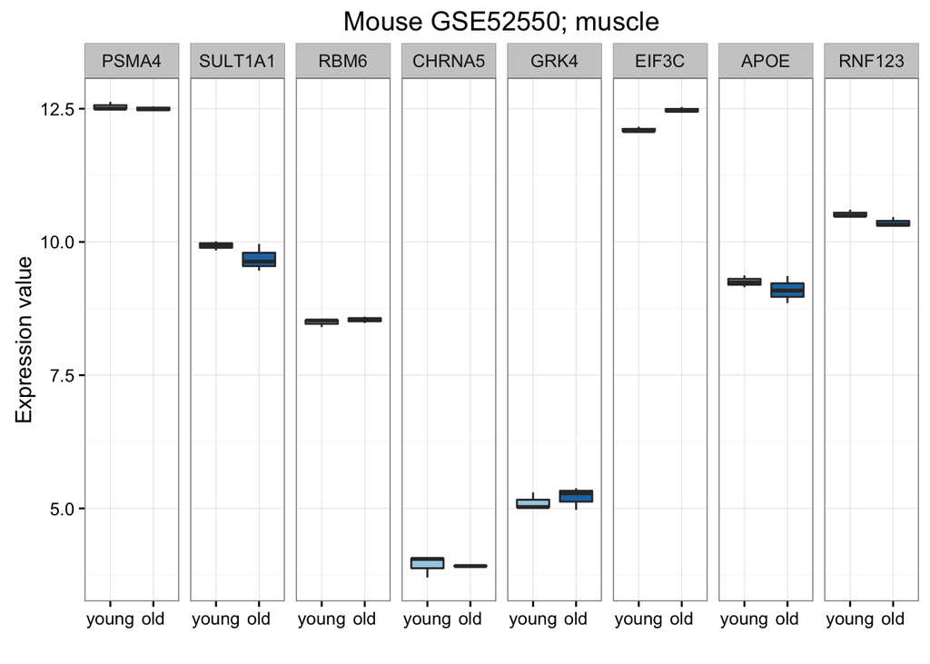

```r
expres.mm.3tissues <- readRDS("~/Results_Project1/final_paper_things/data/02.expression_matrices/expression_matrix_GSE11291_mouse.rds")

expression.3tissues <- lapply(expres.mm.3tissues, function(x) x[[2]])
subset.genes.3tissues <- lapply(expression.3tissues, function(x) {
  mk <- match(mouse.genes$mmusculus_homolog_ensembl_gene, rownames(x))
  x <- x[na.omit(mk), ]
  rownames(x) <- mouse.genes[match(rownames(x),
                                                       mouse.genes$mmusculus_homolog_ensembl_gene),]$external_gene_name
  return(x)})
```

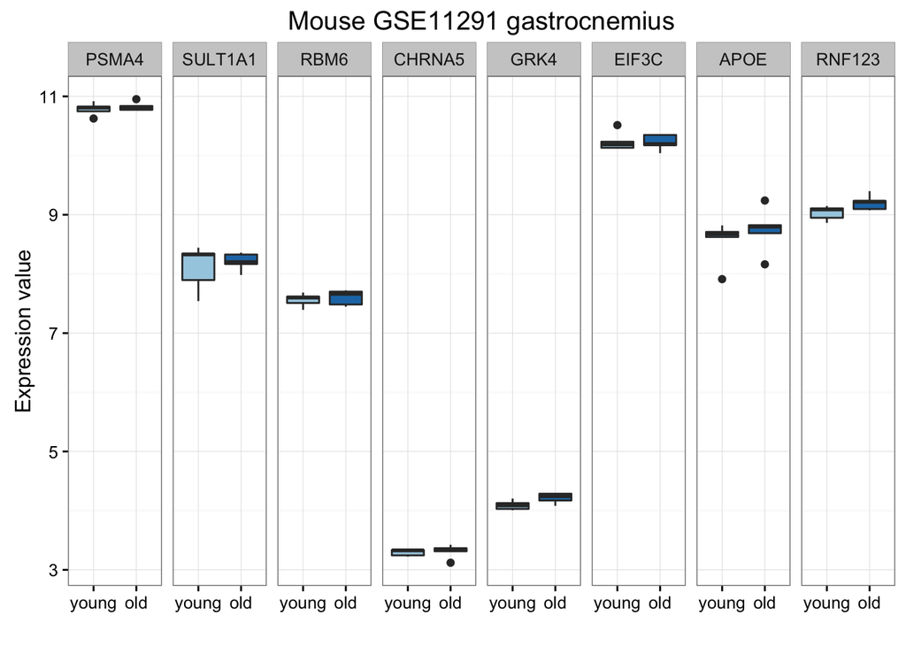

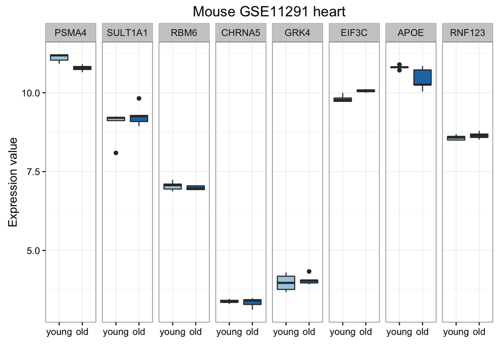

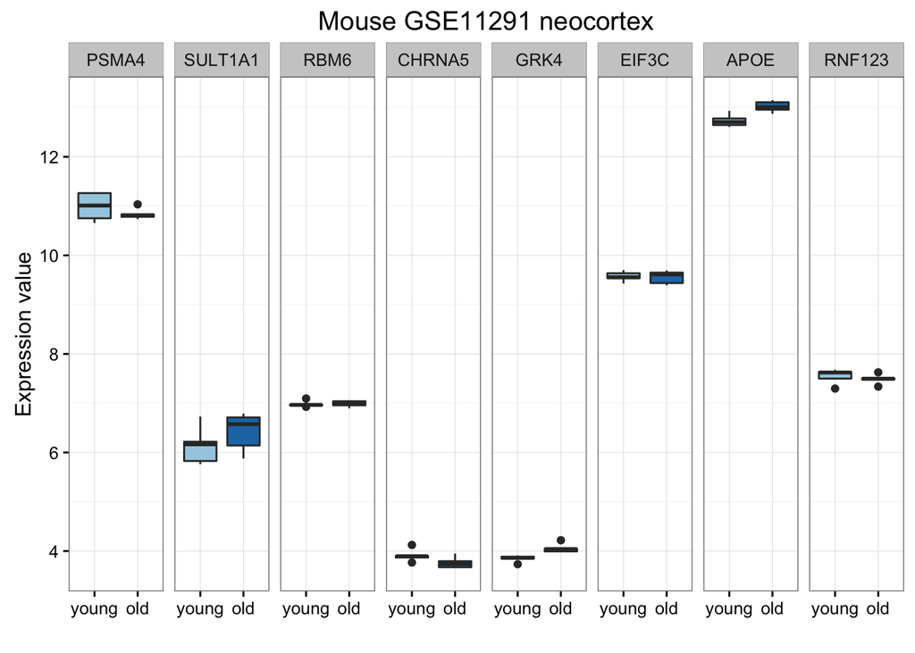

```r
expres.dmel.wholebody2 <- readRDS("~/Results_Project1/final_paper_things/data/02.expression_matrices/expression_matrix_GSE26726_fly_aging.rds")
fly.expr.female.aging <- expres.dmel.wholebody2[[2]]
fly.expr.female.aging <- fly.expr.female.aging[,c(4,5,6,1,2,3)]  # reverse old and young
mkf2 <- match(fly.genes$dmelanogaster_homolog_ensembl_gene, rownames(fly.expr.female.aging))
fly.expr.female.aging<- fly.expr.female.aging[na.omit(mkf2), ]
rownames(fly.expr.female.aging) <- fly.genes[match(rownames(fly.expr.female.aging),
                                                       fly.genes$dmelanogaster_homolog_ensembl_gene),]$external_gene_name
fly.melted.aging.w <- melt(fly.expr.female.aging, id = "x")
```

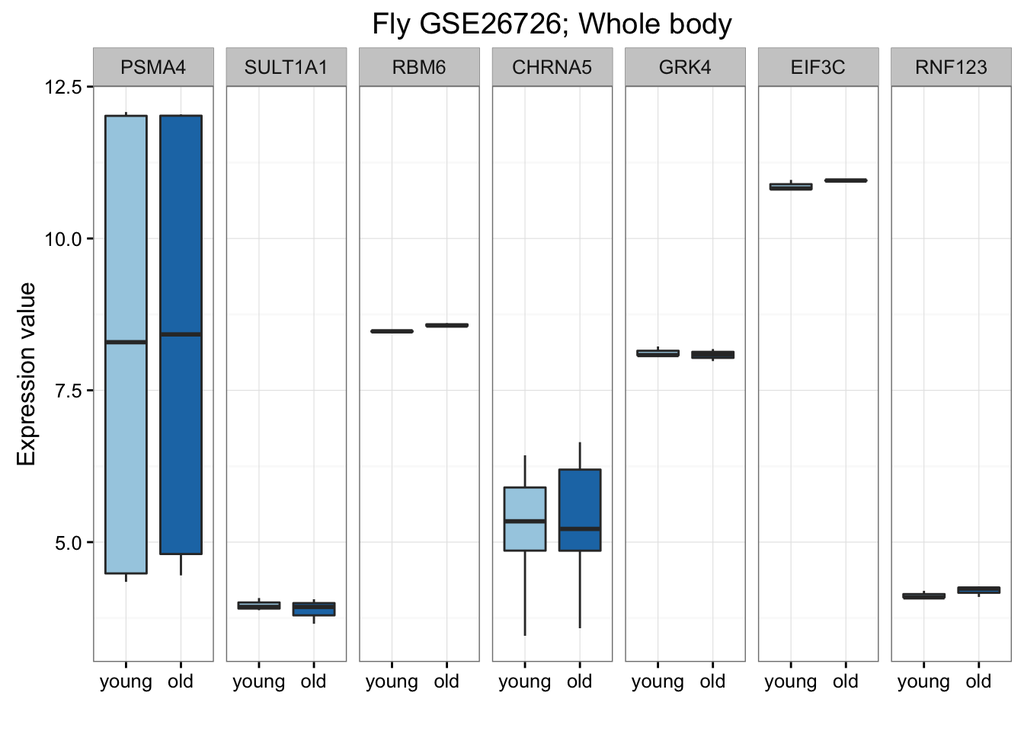

```r
gfag <- ggplot(data = fly.melted.aging.w, aes(x = Var2, y = value, fill = Var2)) +
  theme_bw() +
  geom_boxplot() + ggtitle("Fly GSE26726; Whole body") +
  facet_grid( ~ Var1) + xlab("") + ylab("Expression value")  + scale_fill_brewer(palette = "Paired") +
  theme(legend.position = "none")
plot(gfag)
```

Maybe add the fly RNAseq?

```r
source("/Users/akomljen/Results_Project1/RNAseq_analysis_March2016.R")
directory.fly.male <- '/Users/akomljen/Results_Project1/dmelano/fly_rnaseq_wholebody_SRP26086/'
files.rnaseq.fly.male <- dir(path = directory.fly.male, pattern=".tsv$")
gene.counts.fly.male <- gene.summaries(directory.fly.male, files.rnaseq.fly.male, "dmelanogaster_gene_ensembl", "lengthScaledTPM")

colnames(gene.counts.fly.male$counts) <- c(rep("young", 3), rep("middle", 3),rep("old", 2))
```

```r
## small function for rpkm calc
rpkm.calculation <- function(counts, lengths) {
  rate <- counts / lengths
  return(rate / sum(counts) * 1e9)
}
```

```r
fly.ensembl <- useMart(biomart="ensembl", dataset="dmelanogaster_gene_ensembl")
annot <- getBM(attributes = c("ensembl_gene_id","external_gene_name", "cds_length", "description", "gene_biotype"), filters=c("ensembl_gene_id"),
          values = rownames( gene.counts.fly.male$counts), mart = fly.ensembl, uniqueRows = TRUE)
annot <- annot[complete.cases(annot), ]
gene.length.fly <- aggregate(annot$cds_length, by=list(annot$ensembl_gene_id), max)
```

```r
# taken CDS lengths
gene.counts.fly.male$counts <- as.data.frame(gene.counts.fly.male$counts)
genes.fly.rnaseq <- gene.counts.fly.male$counts[gene.length.fly$Group.1,]
rks <- rpkm.calculation(genes.fly.rnaseq, gene.length.fly$x)
rks <- log2(rks + 1)
rk.set <- rks[fly.genes$dmelanogaster_homolog_ensembl_gene,]
nams <- fly.genes[match(rownames(rk.set),fly.genes$dmelanogaster_homolog_ensembl_gene),]$external_gene_name
rownames(rk.set) <-  make.names(nams, unique=TRUE)
# orth.dmelTohomo <- getBM(attributes = c("ensembl_gene_id", "external_gene_name", "hsapiens_homolog_ensembl_gene", "hsapiens_homolog_orthology_type"), filters = "with_homolog_hsap", values= TRUE, mart = fly.ensembl, bmHeader = FALSE, uniqueRows = TRUE)
# orth.dmelTohomo[orth.dmelTohomo$ensembl_gene_id %in% fly.genes$dmelanogaster_homolog_ensembl_gene,]
fly.gene.set <- melt(as.matrix(rk.set), id = "x")
```

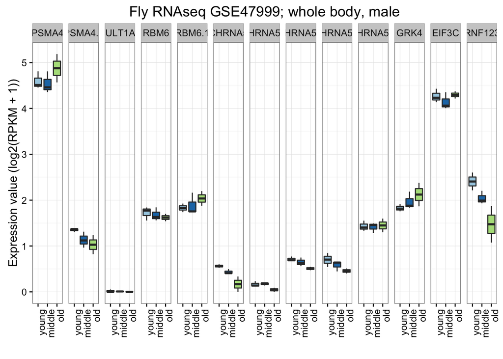

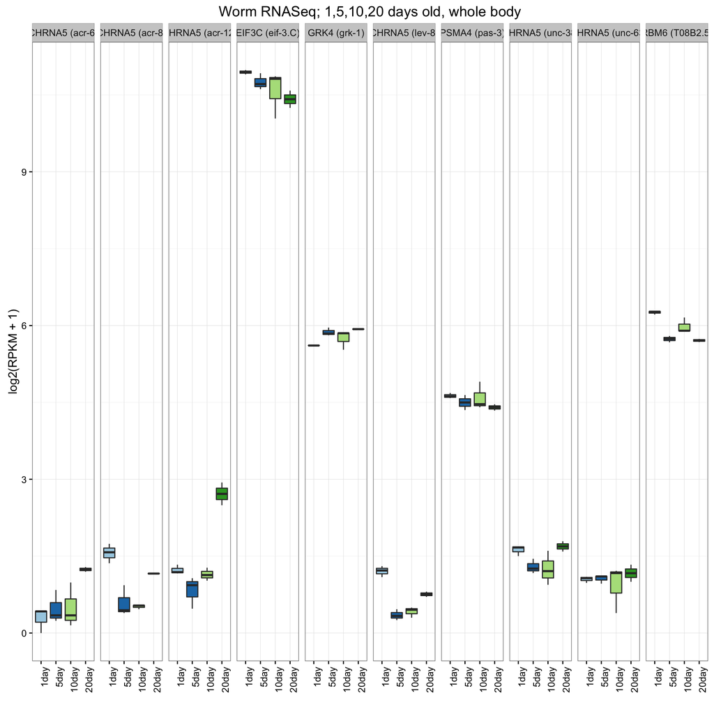

```r
# annotation
ensembl.celegans <- useEnsembl(biomart="ensembl", dataset="celegans_gene_ensembl", version = 85)
orth.celeTohomo <- getBM(attributes = c("ensembl_gene_id", "external_gene_name", "hsapiens_homolog_ensembl_gene", "hsapiens_homolog_orthology_type"), filters = "with_homolog_hsap", values= TRUE, mart = ensembl.celegans, bmHeader = FALSE, uniqueRows = TRUE)
###
worm.gene.names <- orth.celeTohomo[orth.celeTohomo$ensembl_gene_id %in% worm.genes$celegans_homolog_ensembl_gene,]
worm.gene.names <- sapply(split(worm.gene.names$external_gene_name, worm.gene.names$ensembl_gene_id), "[", 1)


require(gdata)
celegans <- read.csv("/Users/akomljen/Documents/GSE46051_ce_22samples_DMSO_Rotenone_counts_and_RPKM.csv", header = TRUE)
# only on the control plates

control.samples <- c("JA1", "JA2", "JA3", "JA10", "JA11", "JA12", "JA19", "JA20", "JA21", "JA28", "JA29") # chosen control samples
control.samples.lab <- c(rep("1day", 3), rep("5day", 3), rep("10day", 3), rep("20day", 2))

celegans <- celegans[!duplicated(celegans$genename), ]
rownames(celegans) <- celegans$genename
cele.cand <- celegans[na.omit(match(worm.gene.names, rownames(celegans))),]
cele.cand.controls <- cele.cand[,control.samples]
colnames(cele.cand.controls) <- control.samples.lab

# ortho.mfw$ToCele[na.omit(match(names(worm.gene.names), ortho.mfw$ToCele$celegans_homolog_ensembl_gene)),]

rownames(cele.cand.controls) <- c("CHRNA5 (acr-6)", "CHRNA5 (acr-8)", "CHRNA5 (acr-12)", "EIF3C (eif-3.C)", "GRK4 (grk-1)", "CHRNA5 (lev-8)", "PSMA4 (pas-3)", "CHRNA5 (unc-38)", "CHRNA5 (unc-63)","RBM6 (T08B2.5)")

worm.melted <- melt(as.matrix(log2(cele.cand.controls + 1)))
gwag <- ggplot(data = worm.melted, aes(x = Var2, y = value, fill = Var2)) +
  theme_bw() +
  geom_boxplot() + ggtitle("Worm RNASeq; 1,5,10,20 days old, whole body") +
  facet_grid( ~ Var1) + xlab("") + ylab("log2(RPKM + 1)")  + scale_fill_brewer(palette = "Paired") +
  theme(legend.position = "none", axis.text.x = element_text(angle = 90, hjust = 1))
plot(gwag)
```

FINAL PDF for aging.

```r
pdf("~/Results_Project1/collaboration_Zoltan_Aaron/results/results_aging_update3_Sep2016.pdf", 10, 10)

# mouse 1
gmag <- ggplot(data = formuscle.mouse, aes(x = Var2, y = value, fill = Var2)) +
  theme_bw() +
  geom_boxplot() + ggtitle("Mouse GSE52550; muscle") +
  facet_grid( ~ Var1) + xlab("") + ylab("Expression value")  + scale_fill_brewer(palette = "Paired") +
  theme(legend.position = "none")
plot(gmag)

# mouse 2
for(i in 1:length(for3tissues)){
  gmag2 <- ggplot(data = for3tissues[[i]], aes(x = Var2, y = value, fill = Var2)) +
    theme_bw() +
    geom_boxplot() + ggtitle(paste("Mouse GSE11291", tissues3[i])) +
    facet_grid(~ Var1) + xlab("") + ylab("Expression value") + scale_fill_brewer(palette = "Paired") +
    theme(legend.position = "none")
  plot(gmag2)
}

# fly 1
gfag <- ggplot(data = fly.melted.aging.w, aes(x = Var2, y = value, fill = Var2)) +
  theme_bw() +
  geom_boxplot() + ggtitle("Fly GSE26726; Whole body") +
  facet_grid( ~ Var1) + xlab("") + ylab("Expression value")  + scale_fill_brewer(palette = "Paired") +
  theme(legend.position = "none")
plot(gfag)

# fly rnaseq
gf.rnaseq <- ggplot(data = fly.gene.set, aes(x = Var2, y = value, fill = Var2)) +
  theme_bw() +
  geom_boxplot() + ggtitle("Fly RNAseq GSE47999; whole body, male") +
  facet_grid( ~ Var1) + xlab("") + ylab("Expression value (log2(RPKM + 1))")  + scale_fill_brewer(palette = "Paired") +
  theme(legend.position = "none",  axis.text.x = element_text(angle = 90, hjust = 1))
plot(gf.rnaseq)

# worm
gwag <- ggplot(data = worm.melted, aes(x = Var2, y = value, fill = Var2)) +
  theme_bw() +
  geom_boxplot() + ggtitle("Worm RNASeq; 1,5,10,20 days old, whole body") +
  facet_grid( ~ Var1) + xlab("") + ylab("log2(RPKM + 1)")  + scale_fill_brewer(palette = "Paired") +
  theme(legend.position = "none", axis.text.x = element_text(angle = 90, hjust = 1))
plot(gwag)

dev.off()
```

##### PART 2. DIETARY RESTRICTION.

```r
mouse.dr <- readRDS("~/Results_Project1/final_paper_things/data/02.expression_matrices/expression_matrix_GSE11291_mouse_dr.rds")
mouse.tissues <- lapply(mouse.dr, function(x)  x[[2]])

subset.genes.dr <- lapply(mouse.tissues, function(x) {
  mk <- match(mouse.genes$mmusculus_homolog_ensembl_gene, rownames(x))
  x <- x[na.omit(mk), ]
  rownames(x) <- mouse.genes[match(rownames(x),
                                                       mouse.genes$mmusculus_homolog_ensembl_gene),]$external_gene_name
  return(x)})
```

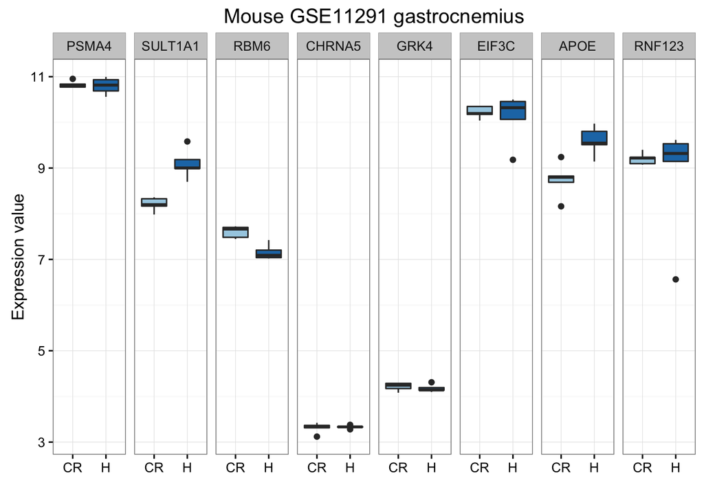

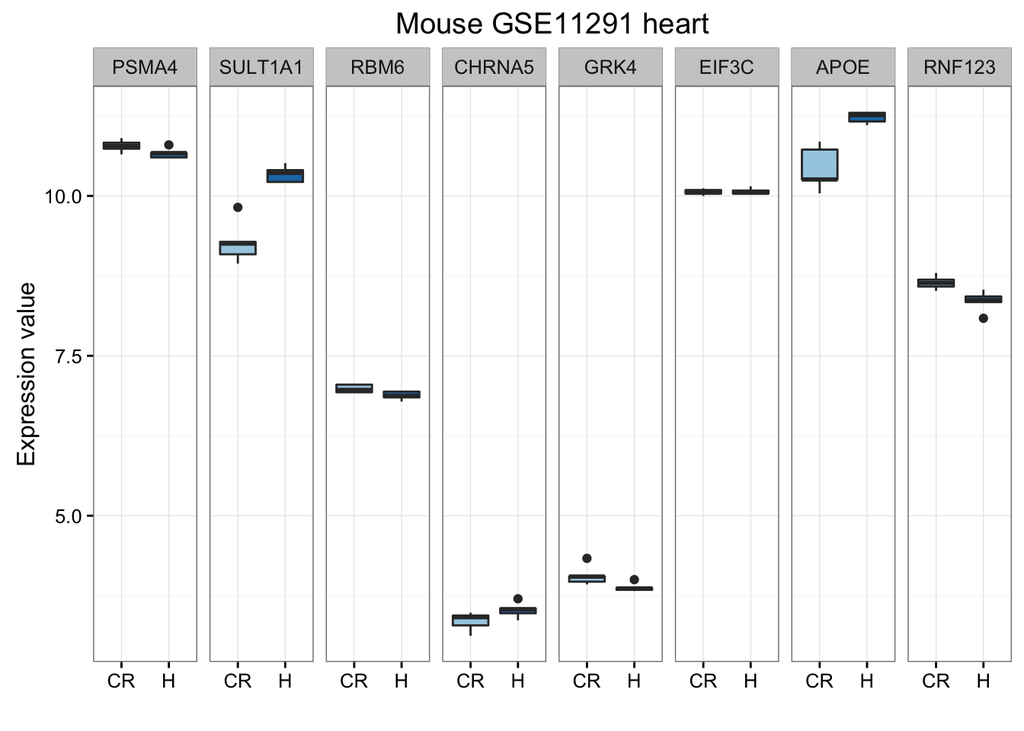

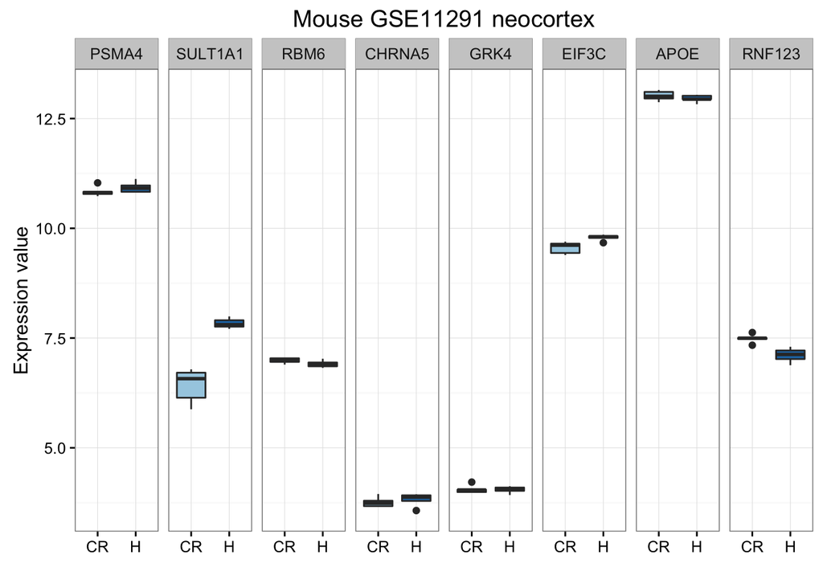

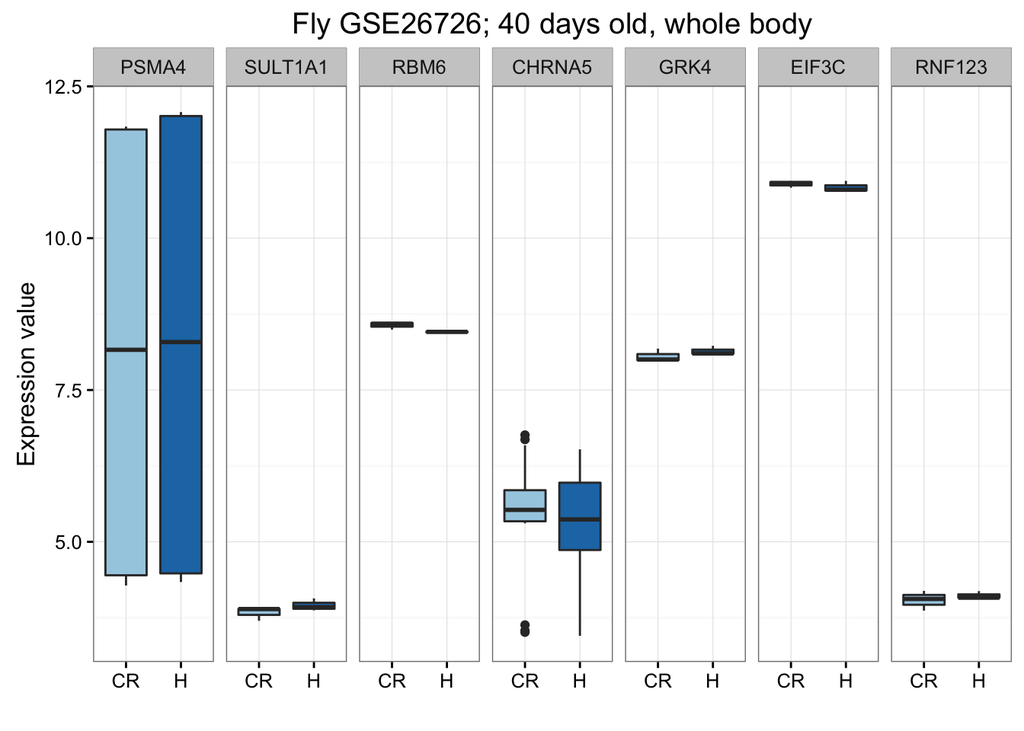

```r
# D. melanogaster
fly.dr <- readRDS("~/Results_Project1/final_paper_things/data/02.expression_matrices/expression_matrix_GSE26726_fly_dr.rds")
fly.expr.dr <- fly.dr$'40 days'[[2]]

mkf <- match(fly.genes$dmelanogaster_homolog_ensembl_gene, rownames(fly.expr.dr))
fly.expr.dr <- fly.expr.dr[na.omit(mkf), , drop = FALSE]
rownames(fly.expr.dr) <- fly.genes[match(rownames(fly.expr.dr),
                                                       fly.genes$dmelanogaster_homolog_ensembl_gene),]$external_gene_name
colnames(fly.expr.dr) <- c(rep("CR",3), rep("H",3)) # name the columns
```

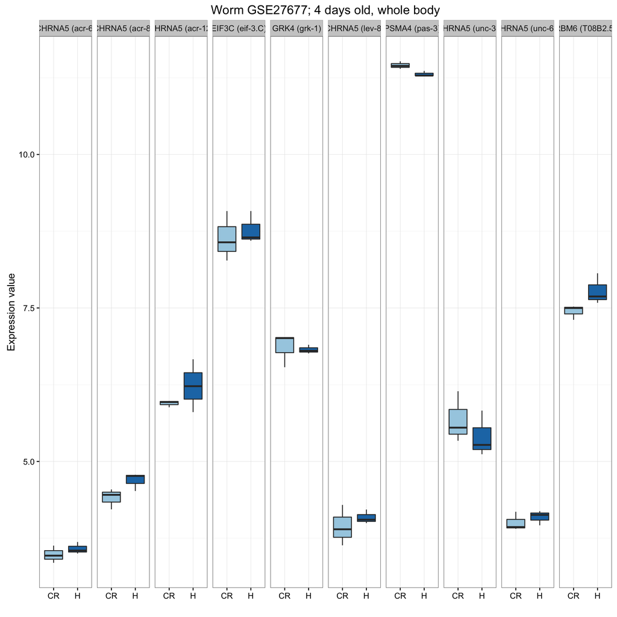

```r
# C. elegans
worm.dr <- readRDS("~/Results_Project1/final_paper_things/data/02.expression_matrices/expression_matrix_GSE27677_worm_dr.rds")
worm.dr.exp <- worm.dr[[2]]

# candidate genes in celegans


mkw <- match(names(worm.gene.names), rownames(worm.dr.exp))
worm.expr.dr <- worm.dr.exp[na.omit(mkw), ]
rownames(worm.expr.dr) <-  c("CHRNA5 (acr-6)", "CHRNA5 (acr-8)", "CHRNA5 (acr-12)", "EIF3C (eif-3.C)", "GRK4 (grk-1)", "CHRNA5 (lev-8)", "PSMA4 (pas-3)", "CHRNA5 (unc-38)", "CHRNA5 (unc-63)","RBM6 (T08B2.5)")
```

FINAL PDF of DR

```r
pdf("~/Results_Project1/collaboration_Zoltan_Aaron/results/results_dietary_restriction_update3_Sep2016.pdf", 10, 10)

# mouse
for(i in 1:length(melted.dr)){
  gm <- ggplot(data = melted.dr[[i]], aes(x = Var2, y = value, fill = Var2)) +
    theme_bw() +
    geom_boxplot() + ggtitle(paste("Mouse GSE11291", tissues.dr[i])) +
    facet_grid(~ Var1) + xlab("") + ylab("Expression value") + scale_fill_brewer(palette = "Paired") +
    theme(legend.position = "none")
  plot(gm)

}

# fly
gf <- ggplot(data = fly.melted.dr, aes(x = Var2, y = value, fill = Var2)) +
  theme_bw() +
  geom_boxplot() + ggtitle("Fly GSE26726; 40 days old, whole body") +
  facet_grid( ~ Var1) + xlab("") + ylab("Expression value")  + scale_fill_brewer(palette = "Paired") +
  theme(legend.position = "none")
plot(gf)

# worm
gw <- ggplot(data = worm.melted.dr, aes(x = Var2, y = value, fill = Var2)) +
  theme_bw() +
  geom_boxplot() + ggtitle("Worm GSE27677; 4 days old, whole body") +
  facet_grid( ~ Var1) + xlab("") + ylab("Expression value")  + scale_fill_brewer(palette = "Paired") +
  theme(legend.position = "none")
plot(gw)

dev.off()
```